# Police Killings and Violence on State Level

Babak Amini

05/24/2022

**Links to spreadsheets**

[prisoner and crime in united state dataset](https://www.kaggle.com/christophercorrea/prisoners-and-crime-in-united-states)

[police killings dataset](https://www.kaggle.com/mysarahmadbhat/police-killings)

**1. Introduction to Crime Datasets**

This data is provided by the Bureau of Justice Statistics along with the FBI Uniform Crime Reporting Statistics. The belief is that locking away criminals with minimum sentencing has decreased violent crime since the 1980s. Therefore, the question is, are these high incarceration rates good for stopping crime, or are they counter productive? In the United States, one quarter of global prisoners are housed. This is obviously a high percentage given the United States is 4% of the global population.

In these datasets, we are looking at how violent crime relates to incarceration and police shootings. This is sparking interest as the death of George Floyd has come about. There are many different factors to study, but instead of making this political, the goal of these datasets is to see correlations between locking people in prison and if states with greater incarceration are incarcerating for violence or not. Additionally, are the states with more violence the states where there are a disproportionate number of police shootings? These questions have been on the public’s mind for several years now, as the news media continues to spark outrage of police brutality.

**2. Questions to Look Into**

1. When states have larger prison populations as a proportion of their state population, are the crimes disproportionately violent compared to states with less of their population incarcerated? This clarifies if states with more prisoners have more prisoners due to mass incarceration, or due to more violence.
2. Do states with more violent crime per capita have more deaths from police shootings to stop crime?
3. Does class status have a correlation with what weapons people carry when they are shot by police?
4. What are the proportion of weapons that make up the most police shootings?
5. How many people are killed by police from each race, and with what weapons were they killed? Are there any differences betweeen the race, and are those difference substantial?

**3. Analysis**

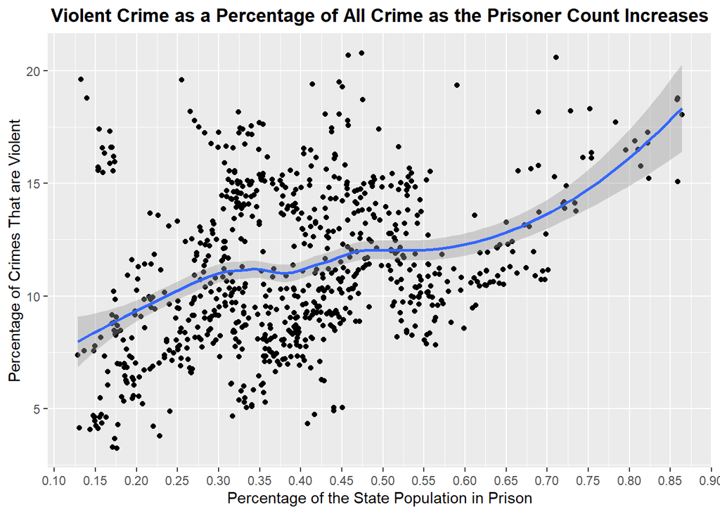

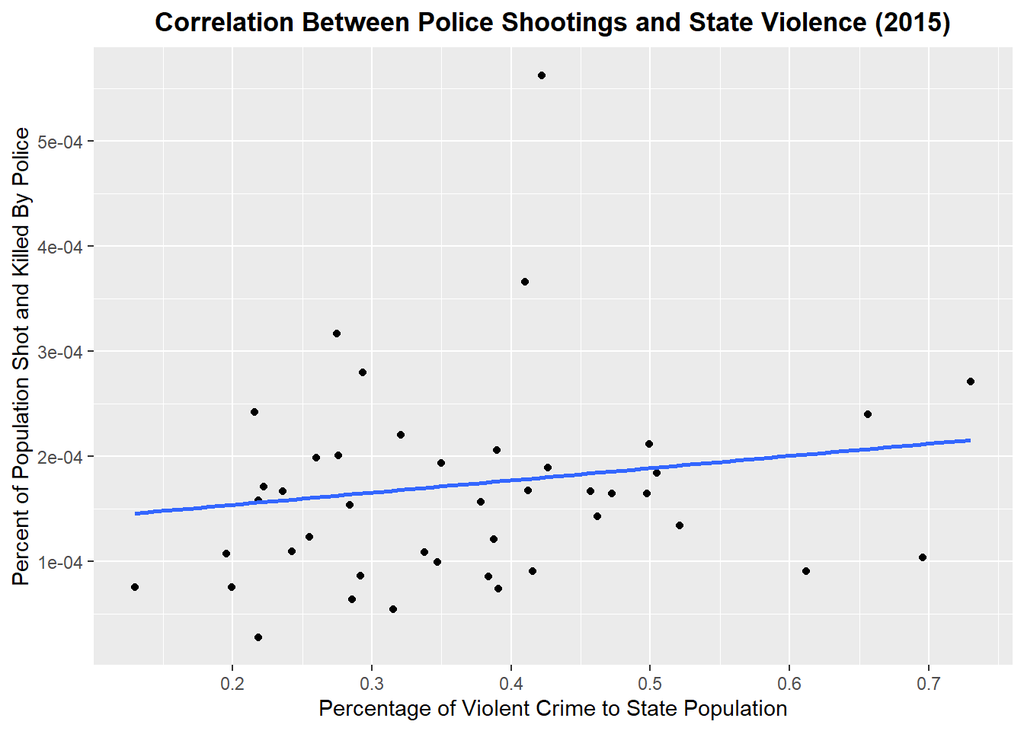

The above figure shows a slight correlation between the amount of violent crime in a state adjusted for population, versus the number of police killings adjusted for population. As the figure shows there are several outliars in the data, with Oklahoma being the state with the most police killings per capita in 2015. Connecticut has the least percentage of their residents killed by police, with a grand total of 1. This result shows that police shootings have less of a relation to state violence than one could expect. It is possible that it has to do with the communities where these shootings are taking place, shown in the fourth graph, where most of the shootings took place in relatively low income areas. Therefore, the number of police shootings based on state violence, despite showing a correlation, is surprising.

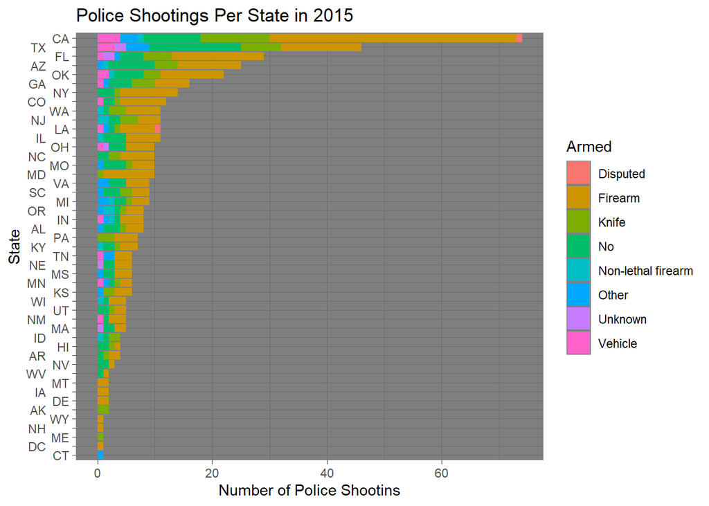

The above figure shows that police shootings are more or less related to population size, with California, Texas, and Florida in the top three for police shootings and also population, in the United States. The data shows that most of those shot and killed by police were armed with a firearm or knife, although the data does not specify if the weapons were legally carried or used during the shooting. About half who were shot, based on the above graph, were armed with a firearm, being the weapon of choice. Vehicles and Unknown arms make up a small percentage of each state’s shootings. These bars suggest that most of those shot had a weapon, meaning that police were not shooting people just to shoot them. This suggests that the police feared for their lives or others when the shooting took place. The reason for this is that most people do not carry a weapon, so the disproportionate number of shooting victims with a weapon suggests the police did not randomly target these individuals. That is not to say that these shooting are justified or not justified, but to say that a potential for reasonable fear is plausible. Justification ought to be decided on a case by case basis.

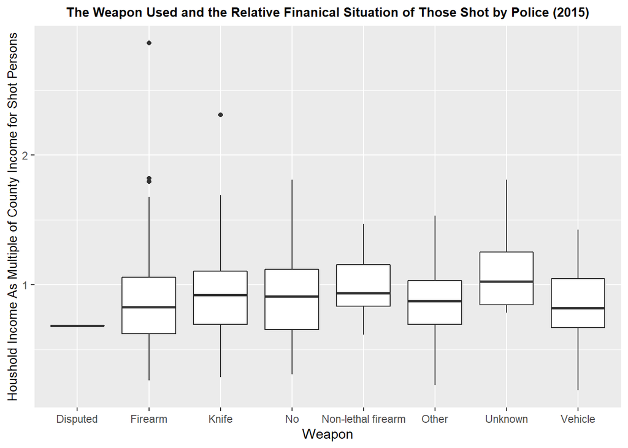

This graph above shows the weapon of preference for those shot and their financial status relative to the county. All median county income multiples by weapon, with the exception of “unknown”, were poorer than their county income. This suggests that police shootings disproportionately occur in economically depressed neighborhoods. There were several outcasts where a firearm user had an income substantially higher than their county. The reason for this is unclear, although it is interesting that firearms has the most outliars. It is possible that, because firearms are legal to carry in most jurisdictions, the demographic of those involved in these shootings are different, in this case the demographic being wealthier individuals. It makes sense that if someone has a firearm on them, they are more likely to get violent, hence more shootings.

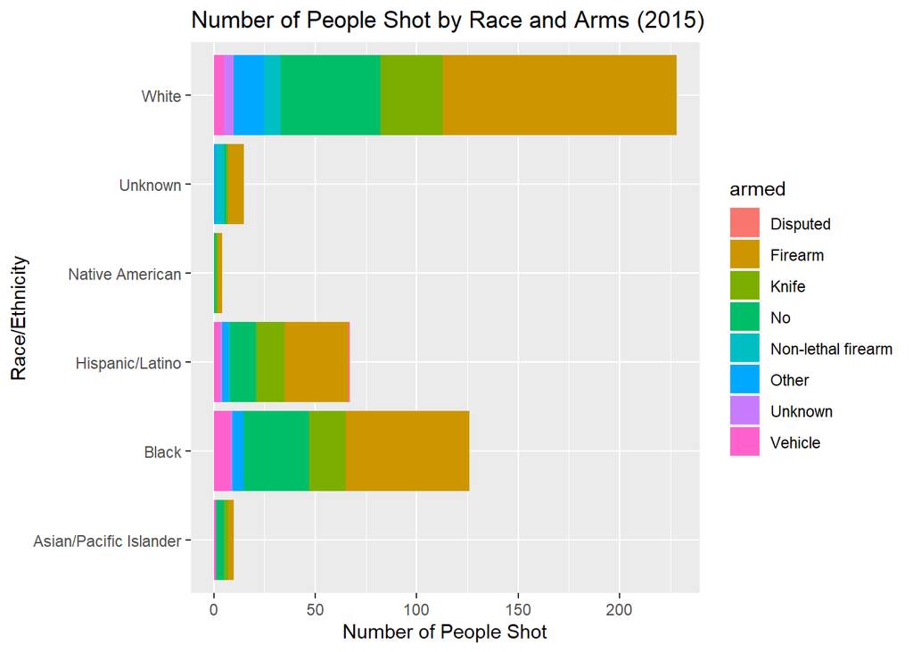

This figure shows that whites are shot the most with blacks the second most. Because the populations differ as well as the violent crime rates between the two races, it is not responsible to say that whites or blacks are over represented in those shot and killed by police. The data also shows that there are not major differences in the weapons being carried by those who were shot and killed. This is interesting since blacks usually live in inner cities where weapon restrictions are greater. However, it is possible that most of these interactions occur in similar types of neighborhoods, resulting in similar shooting victim characteristics, regardless of race.

**References**

1. https://www.kaggle.com/christophercorrea/prisoners-and-crime-in-united-states
2. https://www.kaggle.com/mysarahmadbhat/police-killings

**Acknowledgments**

1. Bureau of Justice Statistics
2. FBI Uniform Crime Reporting Statistics